# Disturbance Explorer Report

###### Date: 2026-06-02

This report summaries disturbance metrics for the chosen study area. The range spans 13200 km², of which **94.6%** is classified as undisturbed and **5.4%** as disturbed. In this analysis, disturbed areas include only features selected for this assessment: buffered anthropogenic disturbances only. Undisturbed areas are defined as all remaining portions of the study area not intersected by these selected disturbances, regardless of the presence of other disturbance types that may exist within the study area but were not included in the analysis.

To generate the disturbed areas layer, a generic buffer of 500 m for linear features and 500 m for areal disturbances were used.

The following disturbance types were present within the study area but excluded from the disturbed areas: mining claims and fires.

No protected areas intersect the study area.

### Summary of landscape condition and disturbances

The following table summarizes disturbance statistics:

[output not shown]

### Spatial overview of the study area

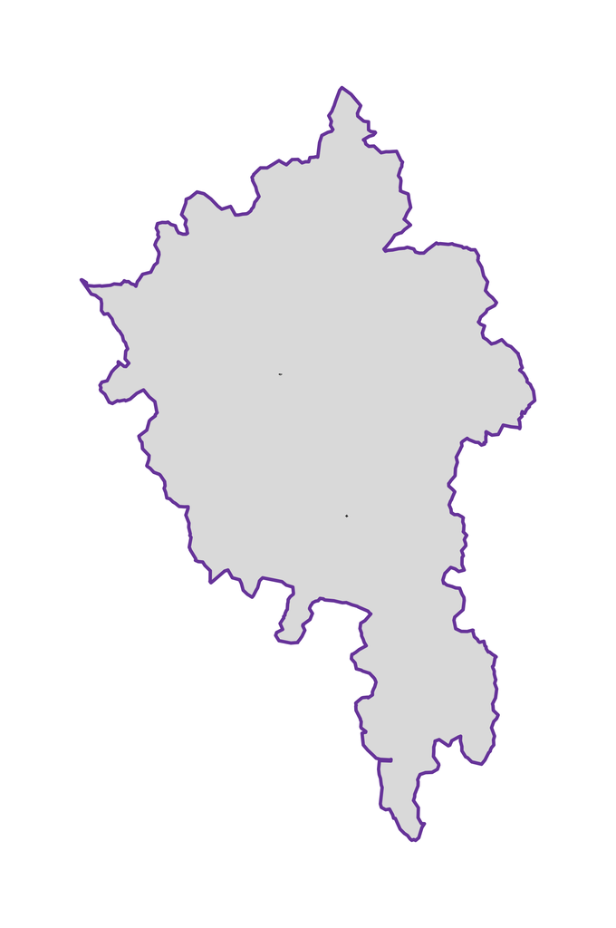

[figure not shown]

### Distance thresholds used per disturbance type to delineate undisturbed areas

This section describe the zone of influence assigned per disturbance industry/type.

#### Areal disturbances

| TYPE_FEATURE | TYPE_INDUSTRY | TYPE_DISTURBANCE | BUFFER_SIZE_M | AREA_KM2 |
| --- | --- | --- | --- | --- |
| Areal | Mining | Quartz Mining - Significant | 500 | 4.27081 |
| Areal | Mining | Quartz Mining - Minor | 500 | 0.73423 |
| Areal | Mining | Mining | 500 | 0.71814 |
| Areal | Mining | Drill Pad | 500 | 0.12092 |
| Areal | Transportation | Clearing | 500 | 0.69298 |
| Areal | Unknown | Unknown | 500 | 0.03277 |
| Areal | Unknown | Clearing | 500 | 0.51308 |
| Areal | Mining | Building | 500 | 0.00296 |
| Areal | Mining | Camp | 500 | 0.10475 |
| Areal | Mining | Gravel Pit / Quarry | 500 | 0.03920 |
| Areal | Mining | Laydown area | 500 | 0.03912 |
| Areal | Transportation | Airstrip | 500 | 0.22875 |
| Areal | Transportation | Road Cut and Fill | 500 | 0.11309 |
| Areal | Transportation | Pullout / Turn Area | 500 | 0.09668 |
| Areal | Transportation | Gravel Pit / Quarry | 500 | 1.42797 |
| Areal | Rural | Homestead | 500 | 0.09416 |
| Areal | Rural | Camp | 500 | 0.19234 |
| Areal | Forestry | Forestry | 500 | 0.01244 |
| Areal | Transportation | Unknown | 500 | 0.13155 |
| Areal | Unknown | Gravel Pit / Quarry | 500 | 0.19899 |
| Areal | Urban | Industrial | 500 | 0.03299 |
| Areal | Urban | Clearing | 500 | 0.14888 |

#### Linear disturbances

| TYPE_FEATURE | TYPE_INDUSTRY | TYPE_DISTURBANCE | BUFFER_SIZE_M | LENGTH_KM |
| --- | --- | --- | --- | --- |
| Linear | Transportation | Access Assumed | 500 | 63.57 |
| Linear | Mining | Survey / Cutline - Quartz | 500 | 38.92 |
| Linear | Transportation | Access Road | 500 | 384.95 |
| Linear | Transportation | Trail | 500 | 44.60 |
| Linear | Mining | Survey / Cutline | 500 | 22.22 |
| Linear | Mining | Unknown | 500 | 0.90 |
| Linear | Transportation | Unpaved Road | 500 | 207.87 |
| Linear | Unknown | Right of Way | 500 | 16.53 |
| Linear | Mining | Trench | 500 | 0.11 |
| Linear | Unknown | Unknown | 500 | 2.02 |
| Linear | Transportation | Local Road | 500 | 13.13 |
| Linear | Utility | Unknown | 500 | 3.44 |
| Linear | Unknown | Survey / Cutline | 500 | 16.64 |
| Linear | Rural | Driveway | 500 | 4.11 |
| Linear | Transportation | Arterial Road | 500 | 223.48 |
| Linear | Transportation | Unknown | 500 | 0.04 |
| Linear | Transportation | Right of Way | 500 | 3.93 |

### Saved statistics and associated parameters

No statistics were saved to the summary statistics table prior to generate the report.

### About this report

This report was generated using the Disturbance Explorer application developed through the BEACONs Project.

If you encounter any issues, have questions regarding the interpretation of the results, or would like additional information, please contact the project team at beacons@ualberta.ca.

When using results or figures derived from this report in presentations, publications, or other materials, please acknowledge the application as follows:

“Generated using the Disturbance Explorer developed through the BEACONs Project.”

The application can be accessed here: https://beaconsproject.shinyapps.io/Disturbance_Explorer/